# Project: Analyzing Soccer Goalscoring Trends

- Introduction
- Data Wrangling
- Exploratory Data Analysis  
  - Q1  
  - Q2  
  - Q3
- Conclusions

## Introduction

Using this data set from kaggle that contains over 25k+ soccer matches from around the world, I want to analyze soccer goal-scoring trends. This involves sifting through all the match data that has been given to us, deciding what is relevant, formatting the relevant data in a way that we can easily analyze, and then effectively communicating our results. The questions I want to tackle are:

> - What type of goals are scored and what are their relative distributions? Does this vary based on the country?
> - Which player has scored the most penalty kicks?
> - Who has scored more goals, Messi or Ronaldo? How does the goal distribution for each of these players differ from one another?

Let's first import all the packages that we'll want to use

```python
# First step is to import what packages we want to use

import IPython
import pandas as pd
import numpy as np
import matplotlib.pyplot as plt
import seaborn as sns
%matplotlib inline
```

## Data Wrangling

### General Properties

```python
# Load your data and print out a few lines. Perform operations to inspect data
#   types and look for instances of missing or possibly errant data.

country_df = pd.read_csv('country.csv')
league_df = pd.read_csv('league.csv')
match_df = pd.read_csv('match.csv')
player_df = pd.read_csv('player.csv')
team_df = pd.read_csv('team.csv')
player_A_df = pd.read_csv('player_attributes.csv')
team_A_df = pd.read_csv('team_attributes.csv')
seq_df = pd.read_csv('sqlite_sequence.csv')
```

```python
# Making sure each table is good, inspecting data

#country_df.head()
#league_df.head()
match_df.head(3)
#player_df.head()
#team_df.head()
#player_A_df.head()
#team_A_df.head()
#seq_df.head()
```

|  | id | country_id | league_id | season | stage | date | match_api_id | home_team_api_id | away_team_api_id | home_team_goal | ... | SJA | VCH | VCD | VCA | GBH | GBD | GBA | BSH | BSD | BSA |
| --- | --- | --- | --- | --- | --- | --- | --- | --- | --- | --- | --- | --- | --- | --- | --- | --- | --- | --- | --- | --- | --- |
| 0 | 1 | 1 | 1 | 2008/2009 | 1 | 2008-08-17 00:00:00 | 492473 | 9987 | 9993 | 1 | ... | 4.0 | 1.65 | 3.40 | 4.50 | 1.78 | 3.25 | 4.00 | 1.73 | 3.40 | 4.20 |
| 1 | 2 | 1 | 1 | 2008/2009 | 1 | 2008-08-16 00:00:00 | 492474 | 10000 | 9994 | 0 | ... | 3.8 | 2.00 | 3.25 | 3.25 | 1.85 | 3.25 | 3.75 | 1.91 | 3.25 | 3.60 |
| 2 | 3 | 1 | 1 | 2008/2009 | 1 | 2008-08-16 00:00:00 | 492475 | 9984 | 8635 | 0 | ... | 2.5 | 2.35 | 3.25 | 2.65 | 2.50 | 3.20 | 2.50 | 2.30 | 3.20 | 2.75 |

3 rows × 115 columns

```python
# Getting a look at the relative sizes of the tables & their components

#country_df.info()
#league_df.info()
match_df.info(verbose=True, null_counts=True) #This table has many columns, hence the inputs
#player_df.info()
#team_df.info()
#player_A_df.info()
#team_A_df.info()
#seq_df.info()
```

```
<class 'pandas.core.frame.DataFrame'>
RangeIndex: 25979 entries, 0 to 25978
Data columns (total 115 columns):
id                  25979 non-null int64
country_id          25979 non-null int64
league_id           25979 non-null int64
season              25979 non-null object
stage               25979 non-null int64
date                25979 non-null object
match_api_id        25979 non-null int64
home_team_api_id    25979 non-null int64
away_team_api_id    25979 non-null int64
home_team_goal      25979 non-null int64
away_team_goal      25979 non-null int64
home_player_X1      24158 non-null float64
home_player_X2      24158 non-null float64
home_player_X3      24147 non-null float64
home_player_X4      24147 non-null float64
home_player_X5      24147 non-null float64
home_player_X6      24147 non-null float64
home_player_X7      24147 non-null float64
home_player_X8      24147 non-null float64
home_player_X9      24147 non-null float64
home_player_X10     24147 non-null float64
home_player_X11     24147 non-null float64
away_player_X1      24147 non-null float64
away_player_X2      24147 non-null float64
away_player_X3      24147 non-null float64
away_player_X4      24147 non-null float64
away_player_X5      24147 non-null float64
away_player_X6      24147 non-null float64
away_player_X7      24147 non-null float64
away_player_X8      24147 non-null float64
away_player_X9      24146 non-null float64
away_player_X10     24146 non-null float64
away_player_X11     24140 non-null float64
home_player_Y1      24158 non-null float64
home_player_Y2      24158 non-null float64
home_player_Y3      24147 non-null float64
home_player_Y4      24147 non-null float64
```

[output cut: 65 more lines]

```
WHA                 22571 non-null float64
SJH                 17097 non-null float64
SJD                 17097 non-null float64
SJA                 17097 non-null float64
VCH                 22568 non-null float64
VCD                 22568 non-null float64
VCA                 22568 non-null float64
GBH                 14162 non-null float64
GBD                 14162 non-null float64
GBA                 14162 non-null float64
BSH                 14161 non-null float64
BSD                 14161 non-null float64
BSA                 14161 non-null float64
dtypes: float64(96), int64(9), object(10)
memory usage: 22.8+ MB
```

## Cleaning the Data

> As we can see from the tables above, there is a lot of irrelevant data for our purposes. Thus we will have to figure out what is important and what isn't, and then we can format our data in such a way that we can easily analyze it

> Straight off the bat we see that "match_df" is the most relevant dataset for our questions and it is also the biggest. However, a lot of this information is stuff we don't care about so lets focus only on what we need. Let's go ahead and drop all the player position columns (as we don't care about formations), and let's drop the betting stats (as we don't care about betting odds either)

```python
# Dropping all the position elements (not useful for our purposes)
match_df1 = match_df.drop(columns = ['home_player_X1',
'home_player_X2', 'home_player_X3','home_player_X4', 'home_player_X5', 'home_player_X6', 'home_player_X7', 'home_player_X8',
'home_player_X9', 'home_player_X10', 'home_player_X11',
'away_player_X1', 'away_player_X2', 'away_player_X3', 'away_player_X4', 'away_player_X5', 'away_player_X6',
'away_player_X7', 'away_player_X8', 'away_player_X9', 'away_player_X10',
'away_player_X11', 'home_player_Y1', 'home_player_Y2', 'home_player_Y3', 'home_player_Y4', 'home_player_Y5',
'home_player_Y6', 'home_player_Y7', 'home_player_Y8', 'home_player_Y9', 'home_player_Y10', 'home_player_Y11', 'away_player_Y1',
'away_player_Y2', 'away_player_Y3', 'away_player_Y4', 'away_player_Y5', 'away_player_Y6', 'away_player_Y7',
'away_player_Y8', 'away_player_Y9', 'away_player_Y10', 'away_player_Y11'])

#Dropping all bettering elements (not useful for our purposes)
match_df1 = match_df1.drop(columns = ['B365H', 'B365D', 'B365A', 'BWH', 'BWD', 'BWA', 'IWH', 'IWD', 'IWA',
'LBH', 'LBD', 'LBA', 'PSH', 'PSD', 'PSA', 'WHH', 'WHD', 'WHA', 'SJH', 'SJD', 'SJA', 'VCH', 'VCD', 'VCA',
'GBH', 'GBD', 'GBA', 'BSH', 'BSD', 'BSA'])
```

Next, let'd drop all the data where the value of the "goal" column is nan (remember, our question is about goal types so no goal information is useless to us)

```python
# Drop NANs
match_df1 = match_df1.dropna(subset=['goal'])
```

Running the next cell just gives you an idea of the changes we've made thus far. Take a look

```python
match_df1.info()
```

[output not shown]

Let's look at what the data looks like inside one of these "goal" catagories:

```python
match_df1.iloc[0,33]
```

```
'<goal><value><comment>n</comment><stats><goals>1</goals><shoton>1</shoton></stats><event_incident_typefk>406</event_incident_typefk><elapsed>22</elapsed><player2>38807</player2><subtype>header</subtype><player1>37799</player1><sortorder>5</sortorder><team>10261</team><id>378998</id><n>295</n><type>…
```

### As you can see from above, we are going to need to sort through this data. It contains a plethora of information such as when the goal was scored, who scored the goal, who assisted it, and so much more all contained as xml data

-- But for our puposes, this is the data we want to extract --

- Who scored the goal
- What type of goal was it

Now there probably is a more glamorous way to do this by learning how to parse through xml data, but I chose to parse the block of text as a string, as this is what I know how to do most naturally.

```python
# Find the length of the column goal. Used as iteration length
length = range(len(match_df1['goal']))
```

```python
# Finds all goal scorers and stores them in a list called "all_scorers"
all_scorers = []
for i in length:
    player_id = []
    match_str1 = match_df1.iloc[i,33]
    for c in range(len(match_str1)):
        if c < (len(match_str1)-7) and c >= 1:
            if match_str1[c:(c+7)] == 'player1' and match_str1[c-1] != '/':
                end = match_str1.index('<',c+8)
                player = match_str1[(c+8):end]
                player_id.append(player)

    # Use this block if you want to have unknown goal scorers in there
    total_goals = (match_df1.iloc[i,9]+ match_df1.iloc[i,10])
    if (len(player_id) != total_goals):
        diff = total_goals - len(player_id)
        for i in range(diff):
            player_id.append("unknown")

    all_scorers.append(player_id)
```

```python
#Finds goal types and stores them in a list called "all_goaltypes"
all_goaltypes = []
for i in length:
    match_str1 = match_df1.iloc[i,33]
    shot_id = []
    for c in range(len(match_str1)):
        if c < (len(match_str1)-7) and c >= 1:
            if match_str1[c:(c+7)] == 'subtype' and match_str1[c-1] != '/':
                end = match_str1.index('<',c)
                shot = match_str1[(c+8):end]
                shot_id.append(shot)
        if c < (len(match_str1)-9) and c >= 1:
            if match_str1[c:(c+9)] == 'penalties' and match_str1[c-1] != '/':
                shot_id.append('penalties')
            if match_str1[c:(c+8)] == 'owngoals' and match_str1[c-1] != '/':
                shot_id.append('owngoals')

    # Use this block if you want to have unknown goal scorers in there
    #total_goals = (match_df1.iloc[i,9]+ match_df1.iloc[i,10])
    total_goals = len(all_scorers[i])
    if (len(shot_id) != total_goals):
        diff = total_goals - len(shot_id)
        for i in range(diff):
            shot_id.append("unknown")
    all_goaltypes.append(shot_id)
```

Now let's add these two lists (all_scorers and all_goaltypes) to our revised match table (match_df1) as two new columns

```python
match_df1["all_scorers"] = all_scorers
```

```python
match_df1["all_goaltypes"] = all_goaltypes
```

Now lets look at our new data table. Scroll all the way to the right after running the next command to see our additional columns

```python
match_df1.head()
```

|  | id | country_id | league_id | season | stage | date | match_api_id | home_team_api_id | away_team_api_id | home_team_goal | ... | goal | shoton | shotoff | foulcommit | card | cross | corner | possession | all_scorers | all_goaltypes |
| --- | --- | --- | --- | --- | --- | --- | --- | --- | --- | --- | --- | --- | --- | --- | --- | --- | --- | --- | --- | --- | --- |
| 1728 | 1729 | 1729 | 1729 | 2008/2009 | 1 | 2008-08-17 00:00:00 | 489042 | 10260 | 10261 | 1 | ... | <goal><value><comment>n</comment><stats><goals... | <shoton><value><stats><blocked>1</blocked></st... | <shotoff><value><stats><shotoff>1</shotoff></s... | <foulcommit><value><stats><foulscommitted>1</f... | <card><value><comment>y</comment><stats><ycard... | <cross><value><stats><crosses>1</crosses></sta... | <corner><value><stats><corners>1</corners></st... | <possession><value><comment>56</comment><event... | [37799, 24148] | [header, shot] |
| 1729 | 1730 | 1729 | 1729 | 2008/2009 | 1 | 2008-08-16 00:00:00 | 489043 | 9825 | 8659 | 1 | ... | <goal><value><comment>n</comment><stats><goals... | <shoton><value><stats><blocked>1</blocked></st... | <shotoff><value><stats><shotoff>1</shotoff></s... | <foulcommit><value><stats><foulscommitted>1</f... | <card /> | <cross><value><stats><crosses>1</crosses></sta... | <corner><value><stats><corners>1</corners></st... | <possession><value><comment>65</comment><event... | [26181] | [shot] |
| 1730 | 1731 | 1729 | 1729 | 2008/2009 | 1 | 2008-08-16 00:00:00 | 489044 | 8472 | 8650 | 0 | ... | <goal><value><comment>n</comment><stats><goals... | <shoton><value><stats><blocked>1</blocked></st... | <shotoff><value><stats><shotoff>1</shotoff></s... | <foulcommit><value><stats><foulscommitted>1</f... | <card><value><comment>y</comment><stats><ycard... | <cross><value><stats><crosses>1</crosses></sta... | <corner><value><stats><corners>1</corners></st... | <possession><value><comment>45</comment><event... | [30853] | [distance] |
| 1731 | 1732 | 1729 | 1729 | 2008/2009 | 1 | 2008-08-16 00:00:00 | 489045 | 8654 | 8528 | 2 | ... | <goal><value><comment>n</comment><stats><goals... | <shoton><value><stats><shoton>1</shoton></stat... | <shotoff><value><stats><shotoff>1</shotoff></s... | <foulcommit><value><stats><foulscommitted>1</f... | <card><value><comment>y</comment><stats><ycard... | <cross><value><stats><crosses>1</crosses></sta... | <corner><value><stats><corners>1</corners></st... | <possession><value><comment>50</comment><event... | [23139, 23139, 127857] | [shot, shot, volley] |
| 1732 | 1733 | 1729 | 1729 | 2008/2009 | 1 | 2008-08-17 00:00:00 | 489046 | 10252 | 8456 | 4 | ... | <goal><value><comment>n</comment><stats><goals... | <shoton><value><stats><blocked>1</blocked></st... | <shotoff><value><stats><shotoff>1</shotoff></s... | <foulcommit><value><stats><foulscommitted>1</f... | <card><value><comment>y</comment><stats><ycard... | <cross><value><stats><corners>1</corners></sta... | <corner><value><stats><corners>1</corners></st... | <possession><value><comment>51</comment><event... | [26165, 40198, 23264, 23264, 23264, 46403] | [header, penalties, shot, header, shot, shot] |

5 rows × 43 columns

Awesome! Now our goal stats are in a more readable format

### Now that we have our scorer data and what type of goal it was, we just need to format it in a way that will be easy to work with!

To answer our questions in the smoothest way possible, let's create a new dataframe called "df_goals" that countains the player who scored the goal, what country they play in, and what type of goal it was.

> This is not as straightforward as just looking at each individual row because each game could have multiple goals with various corresponding goal types. So first lets expand this data out so that each row only contains the information for a single goal

```python
# Creating a new table that just contains the columns we added to match_df1
goal_types = match_df1.iloc[:,41:]
goal_types.info()
```

```
<class 'pandas.core.frame.DataFrame'>
Int64Index: 14217 entries, 1728 to 25948
Data columns (total 2 columns):
all_scorers      14217 non-null object
all_goaltypes    14217 non-null object
dtypes: object(2)
memory usage: 973.2+ KB
```

```python
# Expanding on the information contained in these two columns. The result will be 3 lists that describe
# the country, player, and goal type, for every goal. (The if statment in the for loop is used for goals
# where the player_id is not recorded. This only cut off about 50 data points out of 40,000 so it wasn't
# an issue)

country_list = []
player_list = []
goal_list = []
for i in length:
    if (len(goal_types.iloc[i,0]) == len(goal_types.iloc[i,1])):
        for l in range(len(goal_types.iloc[i,0])):
            player_list.append(goal_types.iloc[i,0][l])
            country_list.append(match_df1.iloc[i,1])
        for r in range(len(goal_types.iloc[i,1])):
            goal_list.append(goal_types.iloc[i,1][r])
```

```python
# Store all 3 of these lists in our new dictionary "df_goals"
d = {'player_api_id': player_list, 'goal_type': goal_list, 'id': country_list}
df_goals = pd.DataFrame(data=d)
df_goals.head()
```

|  | player_api_id | goal_type | id |
| --- | --- | --- | --- |
| 0 | 37799 | header | 1729 |
| 1 | 24148 | shot | 1729 |
| 2 | 26181 | shot | 1729 |
| 3 | 30853 | distance | 1729 |
| 4 | 23139 | shot | 1729 |

Note that the country above is only listed as an id. To get the country name we have to merge this dataframe with the country_df dataframe loaded in the beginning

```python
# Merging country_df with df_goals, on the country id number to analyze goal statistics by country
df = pd.merge(df_goals, country_df, on=['id'])
```

Now that all our data is recorded cleanly in a table, we can analyze the data. Considering that the data is a spread of about 20 categories and we want to see their distribution, a pie or bar chart would be best to analyze this data. I went with a pie chart for visual asthetic. Let's also drop the "unkown" goals, as these add no value to our findings (although they are a substantial percentage of the recorded goals)

## Exploratory Data Analysis

### Q1) What does the scoring breakdown look like? Does it differ between countries? Are there any anomallys in the data?

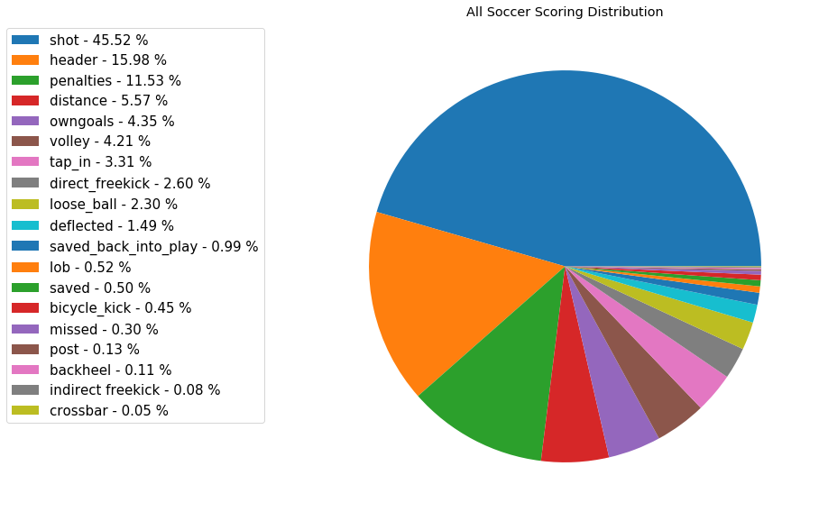

```python
# Drop unknown goal types
df = df[df.goal_type != 'unknown']

# Get data values and labels for pie chart
data = df['goal_type'].value_counts()
labels = df['goal_type'].value_counts().index.tolist()

# Percentage of total will be used for a numerical answer
percent = 100.*data/data.sum()
labels = ['{0} - {1:1.2f} %'.format(i,j) for i,j in zip(labels, percent)]

# Plot the pie chart for the data
plt.figure(figsize=(20,10));
plt.pie(data);
plt.legend(labels, loc='upper right', bbox_to_anchor=(-0.1, 1.), fontsize=15);
plt.title("All Soccer Scoring Distribution");
```

### We finally have a visual on our data! We can use this as a base metric to judge the individual countries distributions

> Now let's repeat this same process to get a pie chart graphic for each country and look at their distributions!

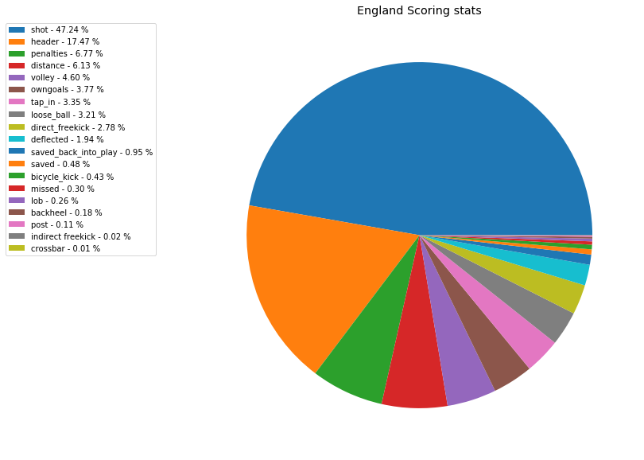

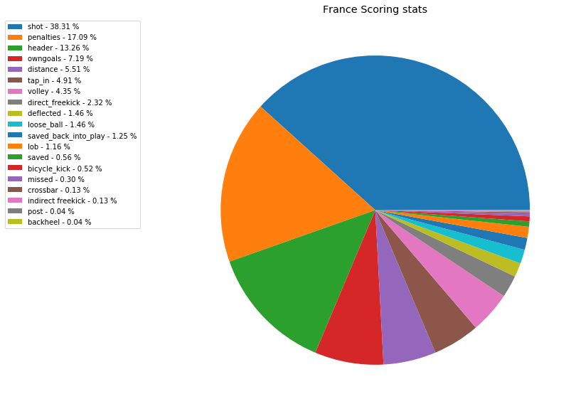

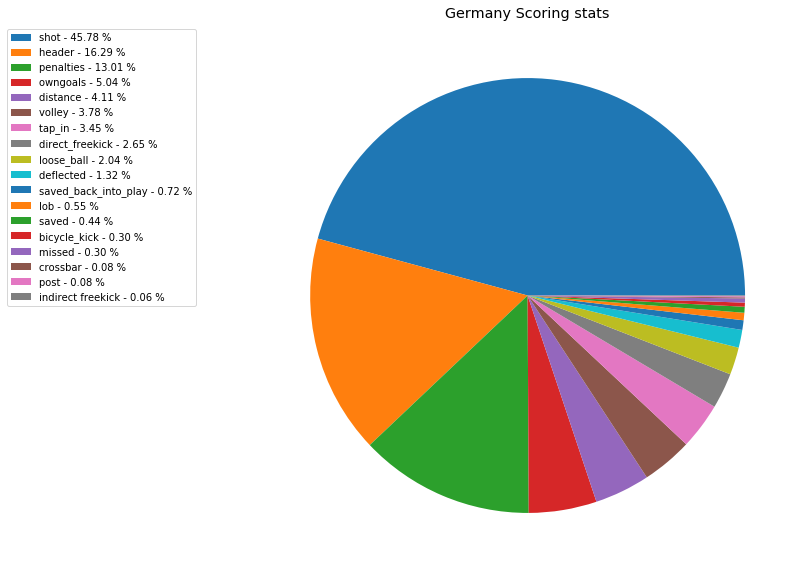

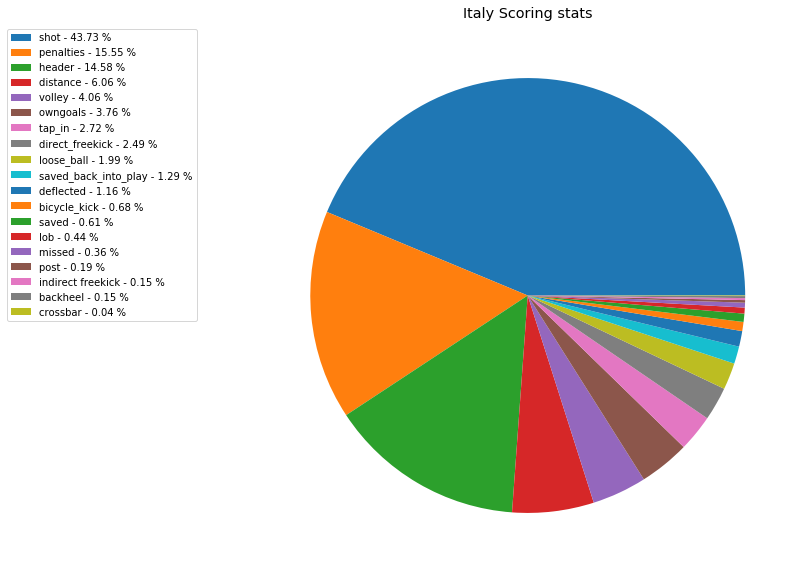

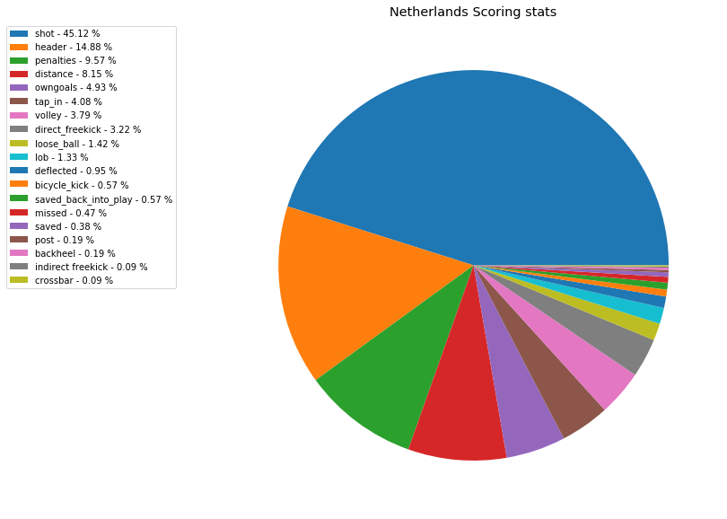

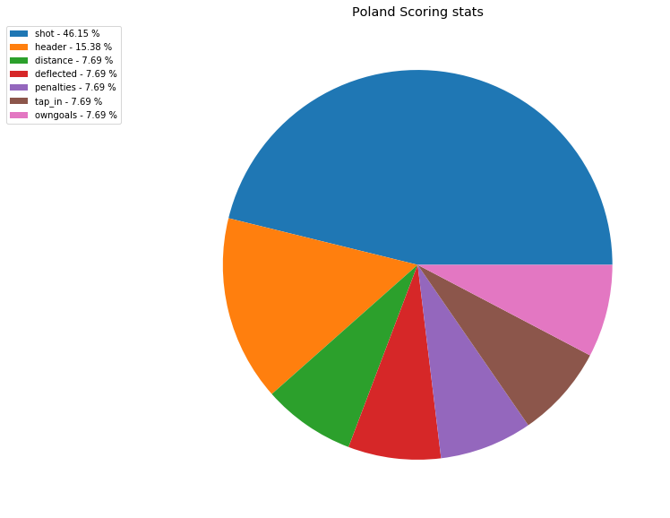

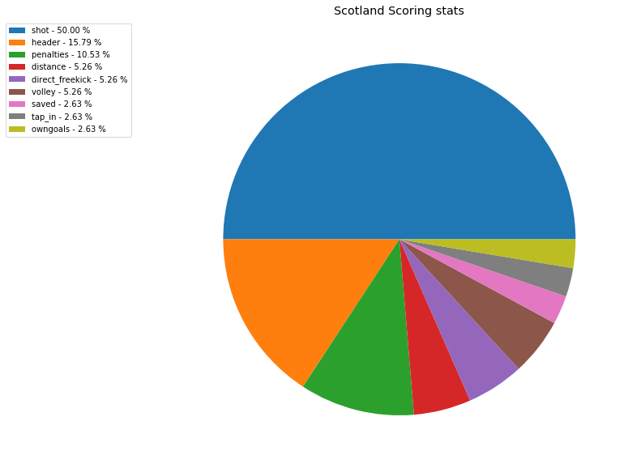

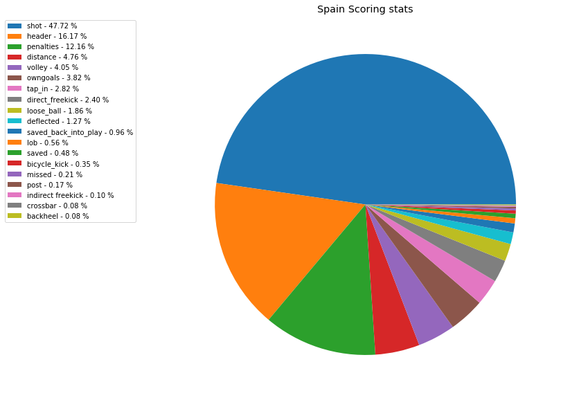

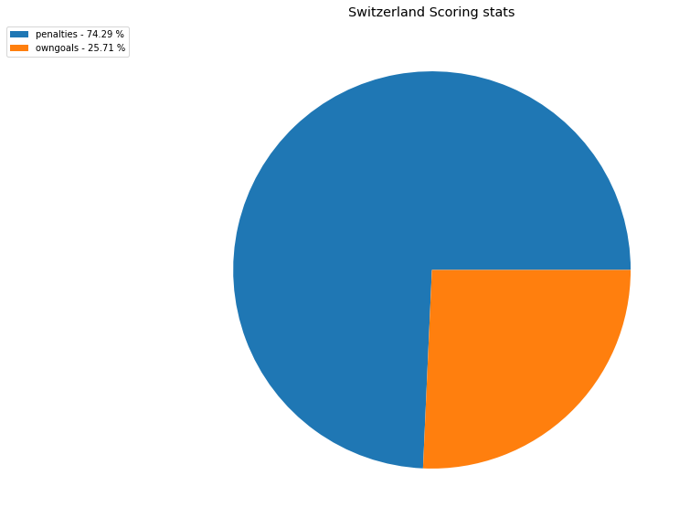

```python
# Group the data by the country name
grouped_goals = df.groupby('name')

# Print out a pie chart with
for i in grouped_goals.groups.keys():
    temp = grouped_goals.get_group(i)
    data = temp['goal_type'].value_counts()
    labels1 = temp['goal_type'].value_counts().index.tolist()
    percent = 100.*data/data.sum()
    labels = ['{0} - {1:1.2f} %'.format(i,j) for i,j in zip(labels1, percent)]

    plt.figure(figsize=(20,10));
    plt.pie(data);
    plt.title(i + " Scoring stats");
    plt.legend(labels, loc='upper right', bbox_to_anchor=(-0.1, 1.), fontsize=10);
```

### Q2) Which player has the most penalties scored?

This involves doing a few things with our data

- First, we can drop all the penalties scored by players with an unknown id. If we don't know who scored the goal then it isn't useful for our data
- Next we need to merge our data set with player_df so that we will be able to see the player name rather than just the id. We want to see who the player with the most goals acutally is after all
- Finally we can drop the irrelevant columns from our new joined dataset. This includes the columns like id (for the country), height, and weight of the player. Store all of this in a new table titled df2

```python
# Merging player_df with df2 on the player api id number to analyze player statistics
df2 = df[df['player_api_id']!='unknown']
df2['player_api_id'] = pd.to_numeric(df2['player_api_id'])
df2 = df2.drop(columns = ['id'])
df2 = pd.merge(df2, player_df, on = ['player_api_id'])
df2 = df2.drop(columns = ['player_fifa_api_id', 'height', 'weight'])
```

```python
# View this new table
df2.head()
```

|  | player_api_id | goal_type | name | id | player_name | birthday |
| --- | --- | --- | --- | --- | --- | --- |
| 0 | 37799 | header | England | 8079 | Obafemi Martins | 1984-10-28 00:00:00 |
| 1 | 37799 | header | England | 8079 | Obafemi Martins | 1984-10-28 00:00:00 |
| 2 | 37799 | distance | England | 8079 | Obafemi Martins | 1984-10-28 00:00:00 |
| 3 | 37799 | shot | England | 8079 | Obafemi Martins | 1984-10-28 00:00:00 |
| 4 | 37799 | shot | England | 8079 | Obafemi Martins | 1984-10-28 00:00:00 |

Now that we have all of the important data stored in one location, lets get some useful information out of it.

- Let's drop any rows with "goal_types" that aren't penalties and then group our results by player_name.
- Then we can store the total number of PKs scored by each individual player in another dataFrame (call it df_penalties).
- Finally we can sort this dataFrame in descending order to get a view of the top goal scorers (this is more helpful than just picking out the max in the dataset)

```python
# We only care about penalties so let's ignore other goal_types. Then we can group the info together by player_name
df2_pen = df2[df2['goal_type']== 'penalties']
grouped_players = df2_pen.groupby('player_name')

pens = []
names = []

# This block of code is filling in 2 lists: One with the player name and one with his associated number of pks scored
for i in grouped_players.groups.keys():
    temp = grouped_players.get_group(i)
    pens.append(len(temp['goal_type']))
    names.append(temp.iloc[0,4])
```

```python
# Create a new data set from the two lists "pens" and "names". Store this in a dataFrame called df_penalties
penalty = {'player_name': names, 'penalties_scored': pens}
df_penalties = pd.DataFrame(data=penalty)
df_penalties.head()
```

|  | player_name | penalties_scored |
| --- | --- | --- |
| 0 | Aaron Hunt | 6 |
| 1 | Abdelkader Ghezzal | 3 |
| 2 | Abdul Majeed Waris | 4 |
| 3 | Abel Hernandez | 4 |
| 4 | Achille Emana | 1 |

```python
# Rather than just searching for the max, lets sort the table in descending order so that we can see who the best PK
# takers are.
df_penalties = df_penalties.sort_values(by = 'penalties_scored', ascending = False)
df_penalties.head()
```

|  | player_name | penalties_scored |
| --- | --- | --- |
| 226 | Cristiano Ronaldo | 49 |
| 1027 | Zlatan Ibrahimovic | 35 |
| 610 | Lionel Messi | 32 |
| 367 | Francesco Totti | 25 |
| 944 | Steven Gerrard | 25 |

#### Thus we see that the player with the most penalty kick goals is Cristiano Ronaldo

### Q3) Who has more goals, Messi or Ronaldo? What types of goals did each of them score?

This can almost be done straight away from df2, but we just have to make a few tweaks

- Query df2 in order to create 2 separate dictionaries; one for Messi and one for Ronaldo
- Drop all data except for the type of goals scored
- Create a dictionary that contains the each goal type and its associated quantity of goals

```python
# Query the data to only have goals scored by Messi. Drop irrelevant information
df_messi = df2.query('player_name == "Lionel Messi"')
df_messi = df_messi.drop(columns = ['birthday','player_api_id','name','id','player_name'])

# Query the data to only have goals scored by Ronaldo. Drop irrelevant information
df_ronaldo = df2.query('player_name == "Cristiano Ronaldo"')
df_ronaldo = df_ronaldo.drop(columns = ['birthday','player_api_id','name','id','player_name'])
```

```python
# See who has more recorded goals
print('Messi: ' + str(len(df_messi.goal_type)) + ' goals')
print('Ronaldo: ' + str(len(df_ronaldo.goal_type))+ ' goals')
```

```
Messi: 293 goals
Ronaldo: 290 goals
```

### Thus we see Messi has more recorded goals then Ronaldo

Now lets continue our investigation to see what types of goals they have scored. Let's try and display the number of goals for each type of goal that both players have scored alongside one another in a bar graph

```python
# Create a dictionary that contains goal info for Messi
messi_dict = {}
for i in range(len(df_messi['goal_type'])):
    key = df_messi.iloc[i,0]
    if key in messi_dict.keys():
        messi_dict[key] += 1
    else:
        messi_dict[key] = 1

# Create a dictionary that contains goal info for Ronaldo
ronaldo_dict = {}
for i in range(len(df_ronaldo['goal_type'])):
    key = df_ronaldo.iloc[i,0]
    if key in ronaldo_dict.keys():
        ronaldo_dict[key] += 1
    else:
        ronaldo_dict[key] = 1
```

```python
# Setting up data and labels for each player to show in a meaningful way
m_labels = messi_dict.keys()
r_labels = ronaldo_dict.keys()

m_data = messi_dict.values()
r_data = ronaldo_dict.values()
```

[figure not shown]

```python
# Plot the goal scoring data of Messi alongside Ronaldo in a bar graph
plt.figure(figsize=(25,10));
plt.bar(height = m_data, x = m_labels, alpha = .5, color = 'b',width = -.4, align = 'edge');
plt.bar(height = r_data, x = r_labels, alpha =.5, color = 'r', width = .4, align = 'edge')
plt.title('Messi vs Ronaldo',{'fontsize':22});
plt.xlabel('Type of goal',{'fontsize':16});
plt.ylabel('Number of goals',{'fontsize':16});
plt.xticks(rotation=45);
plt.legend(['messi','ronaldo'],fontsize='x-large');
```

## Conclusions

Through analyzing the type of goals in this dataset we have found many interesting things. First we saw what the goal breakdown looked like across the world and then compared that to what the goal breakdown looked like for each country's league. We were able to see a couple surprising stats, such as the fact that France has an exceptionally large percentage of penalty kick goals and that on average 4.3% of goals scored are own goals. Personally, I would have imagined the own goal rate to be much lower.

Follwing this we found out that Ronaldo leads the world in penalty kick goals (49) and that Messi has scored more goals than Ronaldo overall (293 to 290). We were also able to see how Messi's goal distribution differed from Ronaldo's.

We were limited in a few ways with our questions. For example, when we were analyzing how the type of goals scored differ based off the country, we were not able to clearly point out why. We showed that France has a much higher percentage of own goals scored and were able to hypothesize a few theories, but we would need to gather more data and investigate further if we wanted to find out why this percentage is so high. In the same way, we can hypothesize that the types of goals Ronaldo scores are different from the types of goals that Messi scores due to their physical differences, but more investigation would be required to attribute this as the main reason.